# Assignment 2

Reuven Herzog

9/21/2020

```r
library(ggplot2)
library(sf)
library(rnaturalearth)
library(tidyverse)
library(ggspatial)
library(cartogram)
library(ggthemes)
```

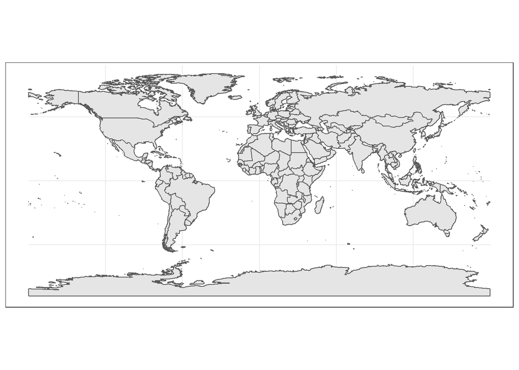

```r
world <- ne_countries(scale = 50, returnclass = "sf")

world_map <- ggplot(world) +
  geom_sf() +
  theme_bw()

world_map
```

## Wading into The Comments Section

Alright, now that we’ve got the boring map out of the way, let’s look for something more interesting…

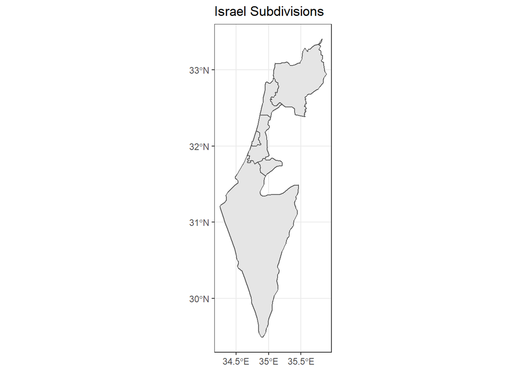

```r
lets_try_something <- ne_states(country = "Israel", returnclass = "sf")
ggplot(lets_try_something) +
  geom_sf() + theme_bw() +
  ggtitle("Israel Subdivisions")
```

Okay. I’ll just note that this data does not include the West Bank or Gaza, and it’s hard to tell but may not include East Jerusalem - but it does include the Golan Heights. Not only that, it includes the UNDOF territory between Israel and Syria that Israel doesn’t even claim! So far, so weird.

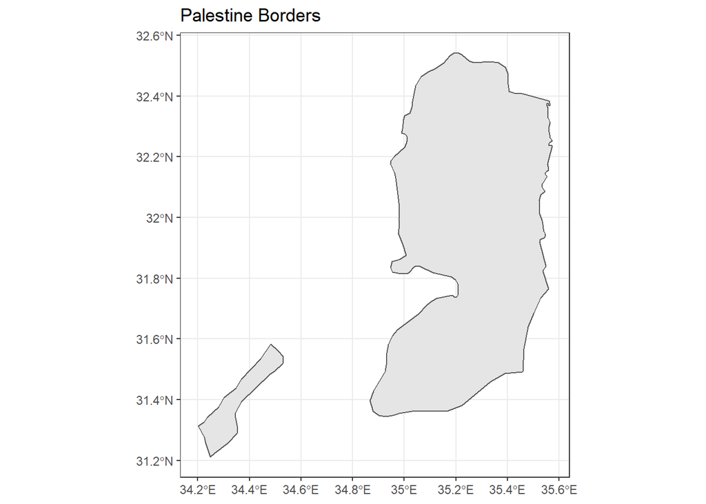

```r
ggplot(ne_countries(country="Palestine", returnclass = "sf", scale = 10)) +
  geom_sf() + theme_bw() +
  ggtitle("Palestine Borders")
```

```r
try({ggplot(ne_states(country="Palestine", returnclass = "sf")) + geom_sf()})
```

```
## Error in ne_states(country = "Palestine", returnclass = "sf") :
##   No such country (Palestine) in the data
```

The dataset includes Palestine as an independent country, but doesn’t include it in the dataset of internal country divisions? This is getting weirder.

And to check that ne_states() should include all countries, regardless of whether they have internal subdivisions or not, let’s try Monaco.

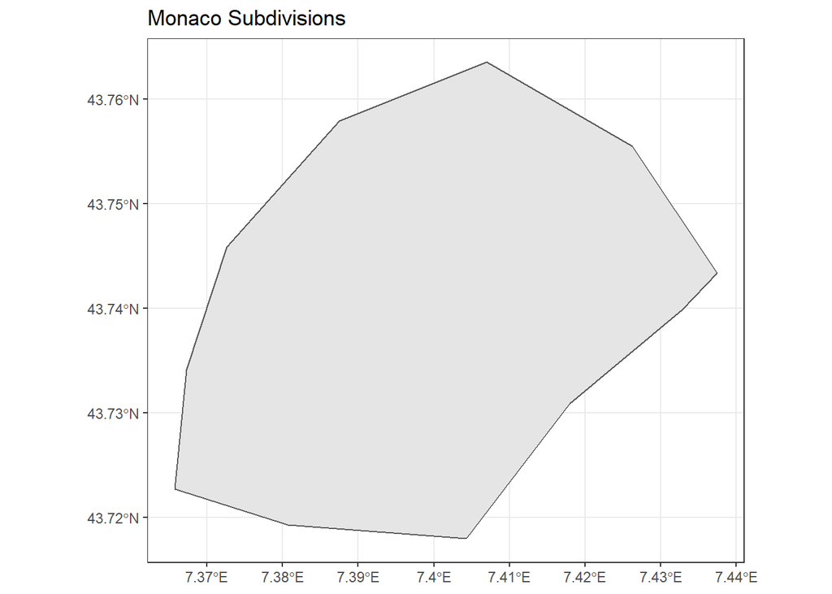

```r
ggplot(ne_states(country = "Monaco", returnclass = "sf")) + geom_sf() + theme_bw() +
  ggtitle("Monaco Subdivisions")
```

At this point, I can only conclude that the party managing the Natural Earth data is very confused. Let’s now move on to countries that are actually large enough for projections to matter.

## America, but with Moose and Healthcare

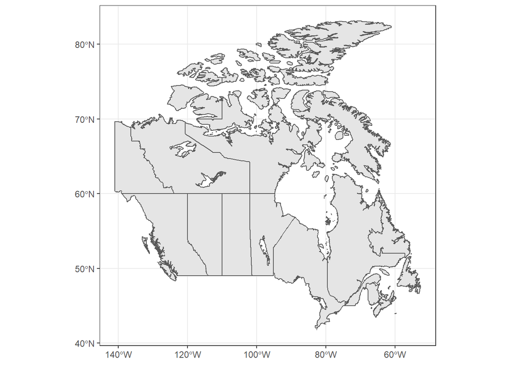

```r
CA_data <- ne_states(country = "Canada", returnclass = "sf")
CA_map <- ggplot(CA_data) + geom_sf() + theme_bw()
CA_map
```

Ew ew ew ew ew. Now for some projections!

First up, worst up:

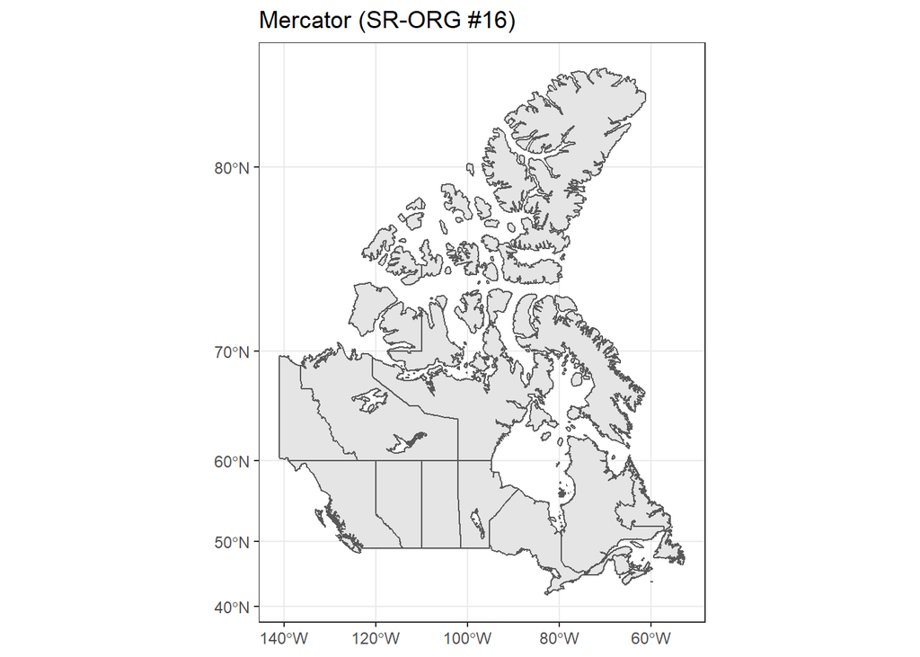

```r
mercator_proj <- "+proj=merc +lon_0=0 +k=1 +x_0=0 +y_0=0 +ellps=WGS84 +datum=WGS84 +units=m +no_defs"

CA_map + coord_sf(crs = mercator_proj) + ggtitle("Mercator (SR-ORG #16)")
```

This uses the Mercator(World) projection, SR-ORG #16. At least the lower provinces look normal, even if Ellesmere Island looks like a full continent.

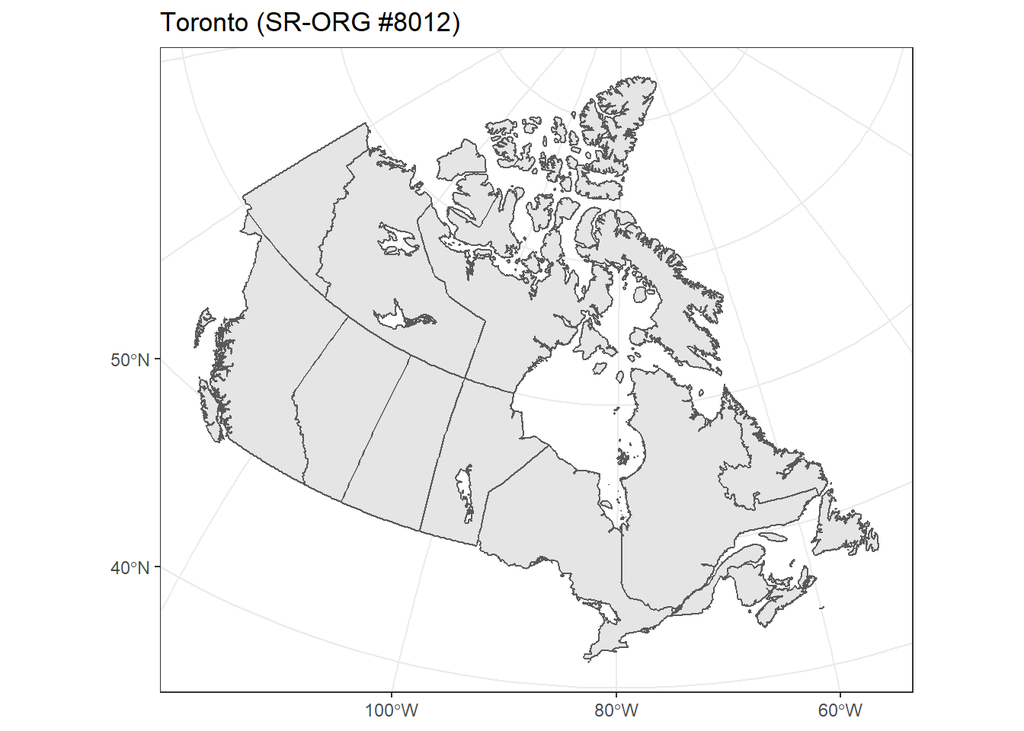

```r
tor_proj <- "+proj=tmerc +lat_0=0 +lon_0=-79.5 +k=0.9999 +x_0=304800 +y_0=0 +ellps=clrk66 +units=m +no_defs"

CA_map + coord_sf(crs = tor_proj) + ggtitle("Toronto (SR-ORG #8012)")
```

I mean, we all know that Toronto is the only thing in Canada that matters anyway… At least in this projection the relative sizes look better.

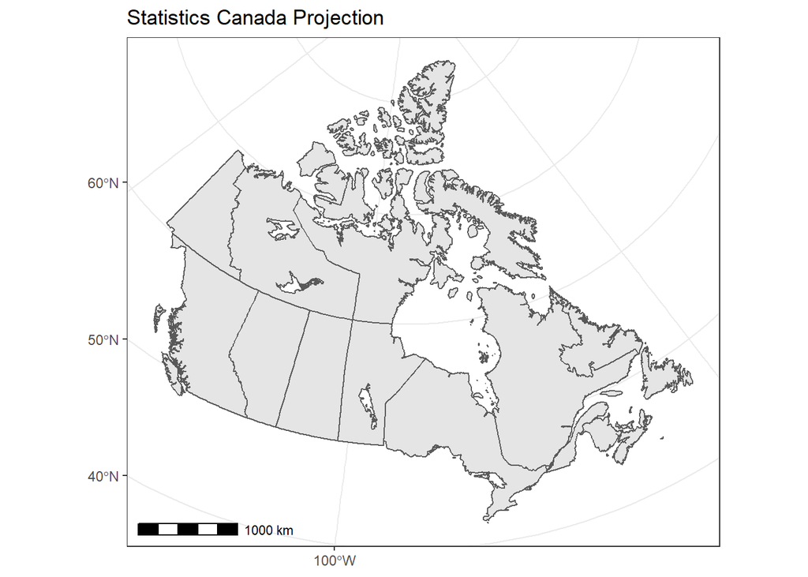

```r
stats_ca <- "+proj=lcc +lat_1=49 +lat_2=77 +lat_0=63.390675 +lon_0=-91.86666666666666 +x_0=6200000 +y_0=3000000 +ellps=GRS80 +datum=NAD83 +units=m +no_defs"
CA_map_std <- CA_map + coord_sf(crs = stats_ca)
CA_map_std + ggtitle("Statistics Canada Projection") + annotation_scale()
```

This is likely the one to settle on, but for now let’s play with other projections.

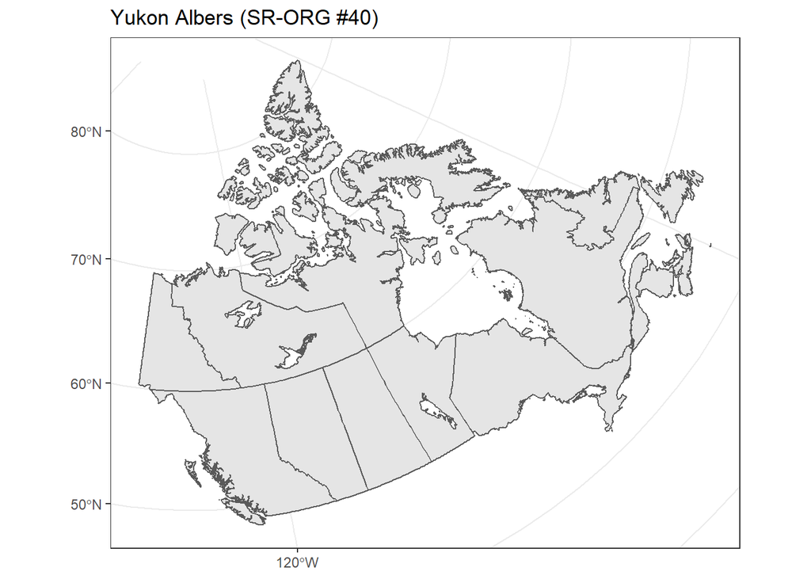

```r
yukon_proj <- "+proj=aea +lat_1=61.66666666667 +lat_2=68 +lat_0=59 +lon_0=-132.5 +x_0=500000 +y_0=500000 +ellps=GRS80 +datum=NAD83 +units=m +no_defs"
CA_map + coord_sf(crs = yukon_proj) + ggtitle("Yukon Albers (SR-ORG #40)")
```

The northern provinces here are definitely enlarged, but distortion is minimal. Let’s try to get one bit crazier:

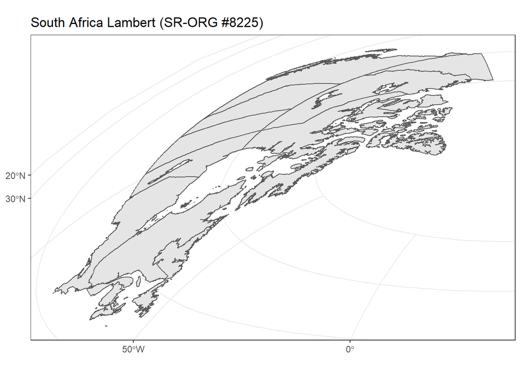

```r
sa <- "+proj=laea +lat_0=-10 +lon_0=35 +x_0=0 +y_0=0 +ellps=WGS84 +units=m +no_defs"
CA_map + coord_sf(crs = sa) + ggtitle("South Africa Lambert (SR-ORG #8225)")
```

Now THAT is some beautiful distortion!

# Part 2 - Maps with GDP Data

Let’s start by loading up our GDP and population data (from Statistics Canada)

```r
ca_pop <- read_csv("C:/Users/Reuven/OneDrive - Harvard University/Fall 2020/VIS/Canada population.csv")
ca_GDP <- read_csv("C:/Users/Reuven/OneDrive - Harvard University/Fall 2020/VIS/Canada GDP.csv") %>%
  mutate(VALUE = VALUE*1000000)
ca_GDP_data <- CA_data %>%
  left_join(ca_pop, by = c("gn_name" = "GEO")) %>%
  rename("Population" = "VALUE") %>%
  left_join(ca_GDP, by = c("gn_name" = "GEO")) %>%
  rename("GDP" = "VALUE") %>%
  mutate("GDP Per Capita" = GDP / Population) %>%
  select("name", "GDP", "Population", "GDP Per Capita")
```

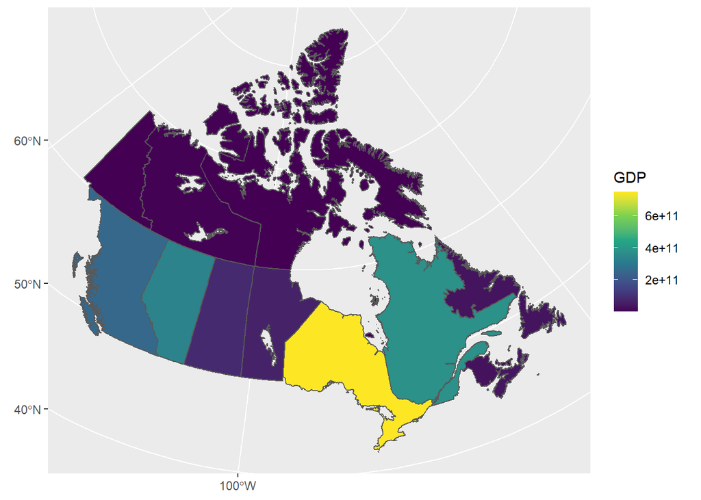

```r
ggplot(ca_GDP_data, aes(fill = GDP)) +
  geom_sf() + coord_sf(crs = stats_ca) +
  scale_fill_viridis_c()
```

And a continuous cartogram, based on population:

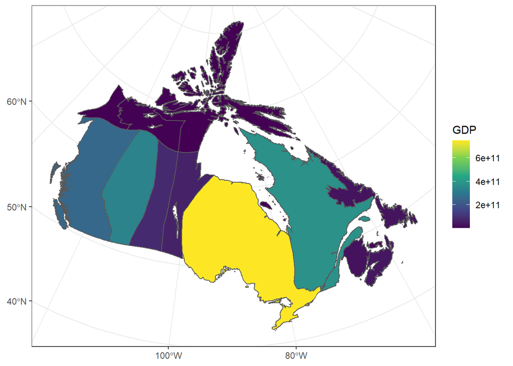

```r
ca_transformed <- st_transform(x = ca_GDP_data, crs = stats_ca)
ca_GDP_cartogram <- ca_transformed %>%
  cartogram_cont(weight = "Population")
ggplot(ca_GDP_cartogram, aes(fill = GDP)) +
  geom_sf() +
  scale_fill_viridis_c() +
  theme_bw()
```

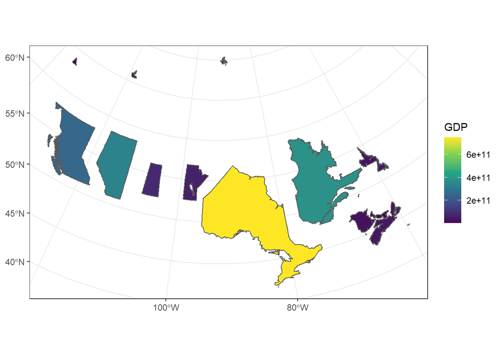

```r
ca_transformed <- st_transform(x = ca_GDP_data, crs = stats_ca)
ca_GDP_ncartogram <- ca_transformed %>%
  cartogram_ncont(weight = "Population")
ggplot(ca_GDP_ncartogram, aes(fill = GDP)) +
  geom_sf() +
  scale_fill_viridis_c() +
  theme_bw()
```

We can abstract this more to a Dorling cartogram.

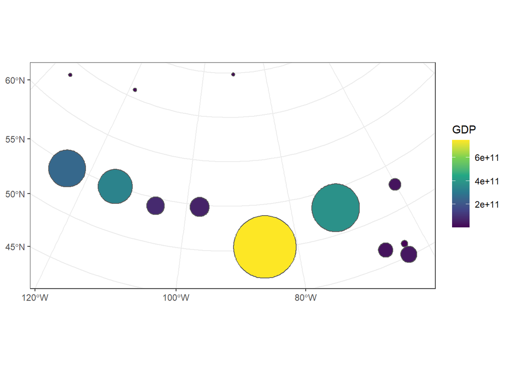

```r
ca_GDP_dorling <- ca_transformed %>%
  cartogram_dorling(weight = "Population")
ggplot(ca_GDP_dorling, aes(fill = GDP)) +
  geom_sf() +
  scale_fill_viridis_c() +
  theme_bw()
```

OK, the non-continuous one is probably harder to read, because the teeny population states are all so far apart.

## Per capita data

We can also look at GDP per capita, and different ways to represent this:

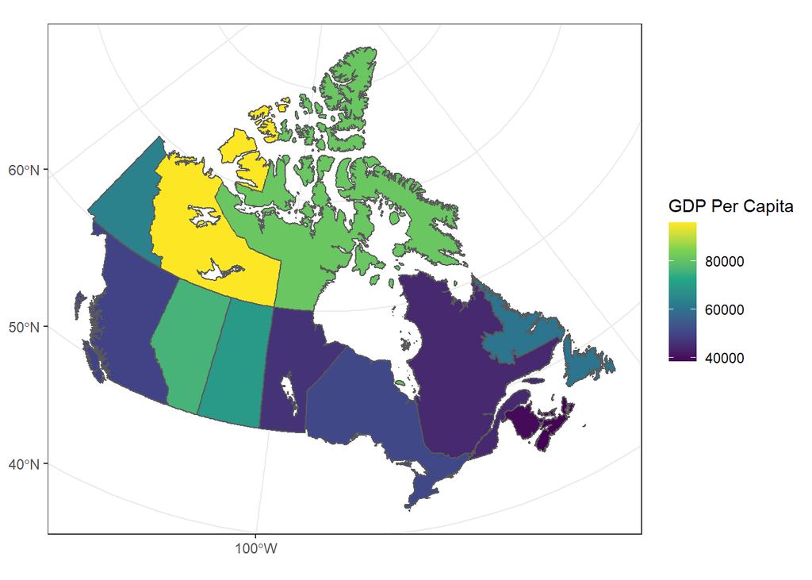

```r
ggplot(ca_transformed, aes(fill = `GDP Per Capita`)) +
  geom_sf() + scale_fill_viridis_c() + theme_bw()
```

Well that was unexpected. I guess I should have looked at the data first if I didn’t want to be surprised. The northern provinces and territories, along with the prairie provinces, have a greater GDP per capita. I suspect this is partially a function of such low population combined with various high-income, mining industries.

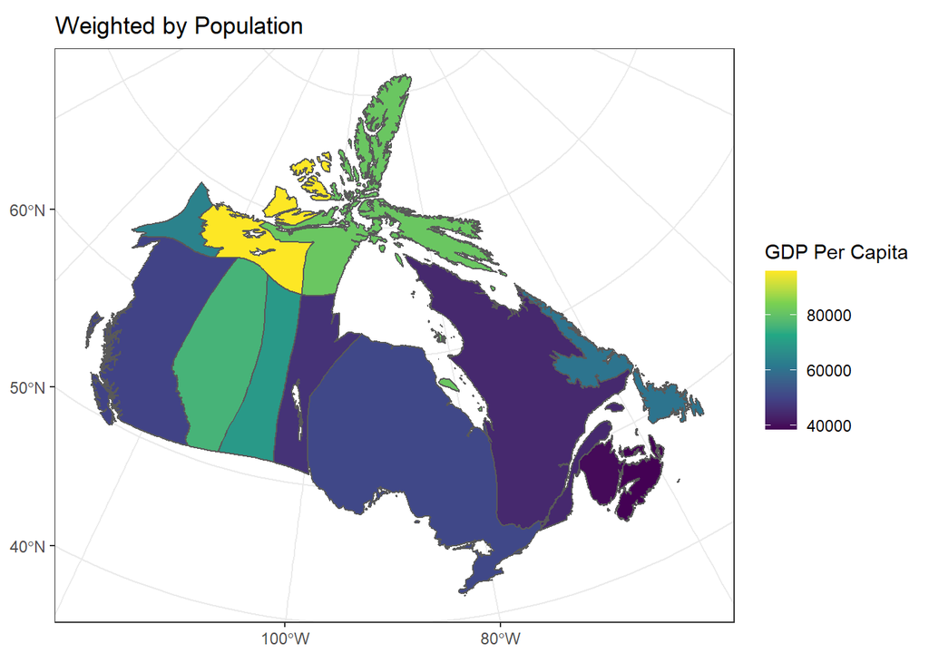

```r
ggplot(ca_GDP_cartogram, aes(fill = `GDP Per Capita`)) +
  geom_sf() +
  scale_fill_viridis_c() +
  theme_bw() +
  ggtitle("Weighted by Population")
```

I’m curious what happens if we weigh the cartogram on GDP instead of population. I actually think it will not change much for the map of GDP per capita:

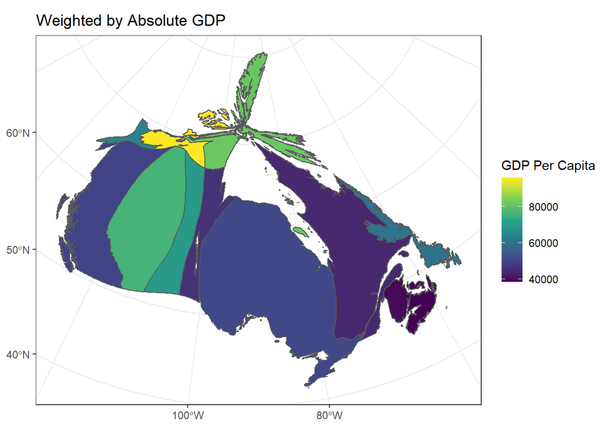

```r
ggplot(cartogram_cont(x = ca_transformed, weight = "GDP"), aes(fill = `GDP Per Capita`)) +
  geom_sf() +
  scale_fill_viridis_c() +
  theme_bw() +
  ggtitle("Weighted by Absolute GDP")
```

Welp, I was wrong. I guess this makes sense: Since the northern territories have so many fewer people than the southern provinces, their higher GDP per capita isn’t significantly higher enough to counteract the absolute number difference.

## Our old friend

Lastly, we cannot forget about non-geographic charts:

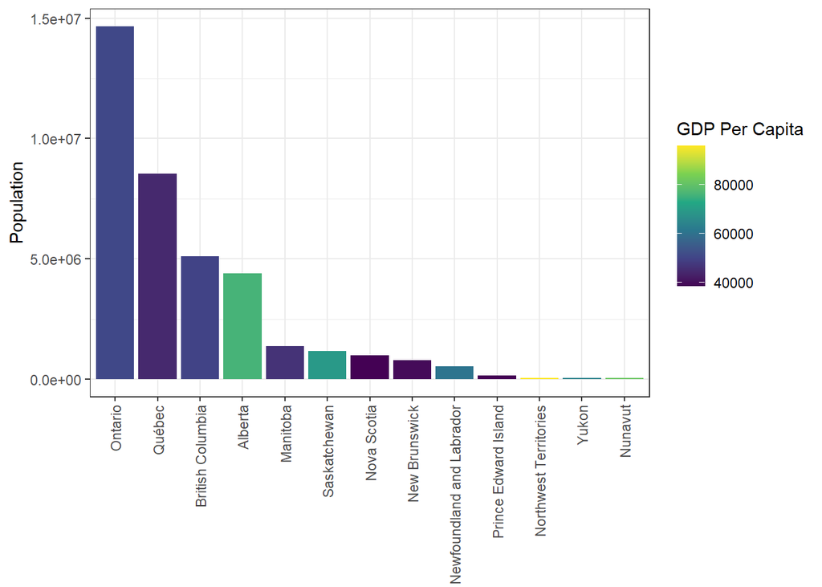

```r
ca_GDP_data$name <- factor(ca_GDP_data$name, levels = ca_GDP_data$name[order(-ca_GDP_data$Population)])
ggplot(ca_GDP_data, aes(y = `Population`, x = `name`, fill = `GDP Per Capita`)) +
  geom_bar(position = position_dodge(), stat = "identity") +
  scale_x_discrete(name = NULL) +
  scale_fill_viridis_c() +
  theme_bw() +
  theme(axis.text.x = element_text(angle = 90, vjust = 0.5, hjust=1))
```